The Living Standards Measurement Study - Integrated Surveys on Agriculture (LSMS-ISA) is a household survey funded by the Gates Foundation and implemented by the World Bank. This representative panel survey is implemented in eight countries, including Tanzania. The survey has a strong focus on agriculture, but includes a variety of other household metrics including those related to Housing, Water and Sanitation, and Finance.The below explores the relationship between variables related to investments in housing and those related to use of mobile money.

To begin, we download the relevant datasets from GitHub.

Get dataset with region data from GitHub:

```r
linkRegions= 'https://github.com/efweavs1989/PUBPOL599B_DATA/blob/master/hh_sec_a.csv?raw=true'

region=read.csv(linkRegions)
```

Get dataset with Section I data from Github:

```r
i_link= 'https://github.com/efweavs1989/PUBPOL599B_DATA/raw/master/hh_sec_i.csv'
i_data= read.csv(i_link)
```

Get dataset with Section Q1 data from Github:

```r
q1_link= 'https://github.com/efweavs1989/PUBPOL599B_DATA/raw/master/hh_sec_q1.csv'
q1_data= read.csv(q1_link)
```

View names to identify which variables need to be kept. Keep household ID, region number, and region name:

```r
names(region)
```

```
##  [1] "occ"         "y4_hhid"     "hh_a06"      "hh_a13"      "y4_rural"
##  [6] "domain"      "strataid"    "clusterid"   "wardtype"    "clustertype"
## [11] "y4_weights"  "hh_a01_1"    "hh_a01_2"    "hh_a02_1"    "hh_a02_2"
## [16] "hh_a03_1"    "hh_a03_2"    "hh_a03_3a"   "hh_a03_3b"   "hh_a04_1"
## [21] "hh_a04_2"    "hh_a05"      "hh_a07_1"    "hh_a07_2"    "hh_a08"
## [26] "hh_a09"      "hh_a10"      "hh_a11"      "hh_a12_2"    "hh_a12_1"
## [31] "hh_a14"      "hh_a15"      "hh_a16"      "hh_a17_1"    "hh_a17_2"
## [36] "hh_a18"      "hh_a18_1"    "hh_a18_2"    "hh_a18_3"    "hh_a19"
## [41] "hh_a20"      "hh_a21"      "hh_a21_1"    "hh_a21_2"    "hh_a21_3"
## [46] "hh_a22"      "hh_a23"      "hh_a24"      "hh_a24_1"    "hh_a24_2"
## [51] "hh_a24_3"    "hh_a25"      "hh_a26"      "hh_a26_1"    "hh_a26_2"
## [56] "hh_a26_3"    "hh_a27"
```

```r
region=region[,c("y4_hhid","hh_a01_1", "hh_a01_2")]
```

View names for Section I data to determine which to keep:

```r
names(i_data)
```

```
##  [1] "occ"      "y4_hhid"  "hh_i01"   "hh_i02"   "hh_i03"   "hh_i04"
##  [7] "hh_i05"   "hh_i06"   "hh_i07_1" "hh_i07_2" "hh_i08"   "hh_i09"
## [13] "hh_i10"   "hh_i11"   "hh_i12"   "hh_i13"   "hh_i14"   "hh_i15"
## [19] "hh_i16"   "hh_i17"   "hh_i18"   "hh_i19"   "hh_i20"   "hh_i21"
## [25] "hh_i22"   "hh_i23"   "hh_i24_1" "hh_i24_2" "hh_i25"   "hh_i26"
## [31] "hh_i27"   "hh_i28"   "hh_i29"   "hh_i30"   "hh_i31"   "hh_i32"
## [37] "hh_i33"   "hh_i34_1" "hh_i34_2" "hh_i35"   "hh_i36"
```

Select variables from Section I to anlayze. These are:

“hh_i05”: In the past year, how much have you paid on repairs to your dwelling? (TSH) “hh_i06”: In the past year, how much have you paid in improvements to your home (excluding any purchases listed in previous question)? (TSH) “hh_i08”: The walls of the main dwelling are predominantly made of what materials? (See questionnaire for options) “hh_i09”: The roof of the main dwelling is predominantly made of what materials? (See questionnaire for options) “hh_i10”: The floor of the main dwelling is predominantly made of what materials? (See questionnaire for options)

```r
i_data=i_data[,c("y4_hhid","hh_i05","hh_i06","hh_i08","hh_i09","hh_i10")]
```

View names from Section Q1 data to determine which namesto keep:

```r
names(q1_data)
```

```
##  [1] "occ"      "y4_hhid"  "hh_q01_1" "hh_q01_2" "hh_q01_3" "hh_q01_4"
##  [7] "hh_q02"   "hh_q03_a" "hh_q03_b" "hh_q03_c" "hh_q03_d" "hh_q03_e"
## [13] "hh_q03_f" "hh_q03_g" "hh_q03_h" "hh_q04"   "hh_q05_1" "hh_q05_2"
## [19] "hh_q06"   "hh_q07"   "hh_q08"   "hh_q09_1" "hh_q09_2" "hh_q09_3"
## [25] "hh_q10"   "hh_q11_1" "hh_q11_2" "hh_q11_3" "hh_q12"   "hh_q13_1"
## [31] "hh_q13_2" "hh_q13_3" "hh_q14"
```

Select variables from Section Q that want to anlayze. These are:

“hh_q01_1”: Did you or anyone in your household use M-PESA to transfer money over the last 12 months “hh_q01_2”: Did you or anyone in your household use EZY PESA to transfer money over the last 12 months “hh_q01_3”: Did you or anyone in your household use Airtel Money to transfer money over the last 12 months “hh_q01_4”: Did you or anyone in your household use TIGO PESA to transfer money over the last 12 months

```r
q1_data=q1_data[,c("y4_hhid","hh_q01_1","hh_q01_2","hh_q01_3","hh_q01_4")]
```

Merge data sets. Need to merge one by one.

```r
i_reg=merge(region,i_data)
projectData=merge(i_reg,q1_data)
```

Check the data type to determine how to aggregate the data.

```r
str(projectData)
```

```
## 'data.frame':    3352 obs. of  12 variables:
##  $ y4_hhid : Factor w/ 3352 levels "1000-001","1001-001",..: 1 2 3 4 5 6 7 8 9 10 ...
##  $ hh_a01_1: int  2 2 2 2 2 2 2 2 2 2 ...
##  $ hh_a01_2: Factor w/ 30 levels "ARUSHA","DAR ES SALAAM",..: 1 1 1 1 1 1 1 1 1 1 ...
##  $ hh_i05  : int  0 0 0 0 0 0 0 0 0 0 ...
##  $ hh_i06  : int  0 0 350000 0 0 0 0 0 0 0 ...
##  $ hh_i08  : int  4 4 6 4 4 2 2 5 6 5 ...
##  $ hh_i09  : int  4 4 4 4 4 4 4 4 4 4 ...
##  $ hh_i10  : int  1 2 2 1 2 1 1 2 2 2 ...
##  $ hh_q01_1: int  1 2 2 2 1 1 1 1 2 1 ...
##  $ hh_q01_2: int  2 2 2 2 2 2 2 2 2 2 ...
##  $ hh_q01_3: int  1 2 2 2 2 2 2 2 2 2 ...
##  $ hh_q01_4: int  2 2 2 2 2 2 2 2 2 2 ...
```

Rename the variables of interest:

```r
names(projectData)=gsub("y4_hhid", "Household_ID", names(projectData))
names(projectData)=gsub("hh_a01_1", "Region_Code", names(projectData))
names(projectData)=gsub("hh_a01_2", "Region_Name", names(projectData))
names(projectData)=gsub("hh_i05", "Value_of_Repairs", names(projectData))
names(projectData)=gsub("hh_i06", "Value_of_Improvements", names(projectData))
names(projectData)=gsub("hh_i08", "Wall_Material", names(projectData))
names(projectData)=gsub("hh_i09", "Roof_Material", names(projectData))
names(projectData)=gsub("hh_i10", "Floor_Material", names(projectData))
names(projectData)=gsub("hh_q01_1", "MPesa_Use", names(projectData))
names(projectData)=gsub("hh_q01_2", "Ezy_Pesa_Use", names(projectData))
names(projectData)=gsub("hh_q01_3", "Airtel_Use", names(projectData))
names(projectData)=gsub("hh_q01_4", "Tigo_Pesa_Use", names(projectData))
```

Double check the names in projectData:

```r
names(projectData)
```

```
##  [1] "Household_ID"          "Region_Code"
##  [3] "Region_Name"           "Value_of_Repairs"
##  [5] "Value_of_Improvements" "Wall_Material"
##  [7] "Roof_Material"         "Floor_Material"
##  [9] "MPesa_Use"             "Ezy_Pesa_Use"
## [11] "Airtel_Use"            "Tigo_Pesa_Use"
```

The primary variable of interest is the value of improvements (how much each household paid for improvements to their home in the past year).

First, aggregate all variables that can be aggregated by the mean:

```r
(mean_variables=aggregate(cbind(Value_of_Repairs, Value_of_Improvements, MPesa_Use, Ezy_Pesa_Use, Airtel_Use, Tigo_Pesa_Use) ~ Region_Code, data=projectData, FUN=mean))
```

```
##    Region_Code Value_of_Repairs Value_of_Improvements MPesa_Use
## 1            1        53194.444             57006.944  1.722222
## 2            2         3238.636             17136.364  1.556818
## 3            3        52390.625             59210.938  1.453125
## 4            4        17750.000             17510.417  1.770833
## 5            5        29267.857             23535.714  1.642857
## 6            6        43208.333              3013.889  1.763889
## 7            7        88579.710             40155.797  1.561594
## 8            8        37250.000              3636.364  1.909091
## 9            9        18715.278             32666.667  1.951389
## 10          10        36388.889             16208.333  1.555556
## 11          11        56886.364             10454.545  1.454545
## 12          12        26714.286             30000.000  1.473214
## 13          13        14892.857             33771.429  1.446429
## 14          14        31645.903             14673.611  1.750000
```

[output cut: 47 more lines]

Now aggregate those variables that need to be aggregated by mode. To do this we need to first create a function which calculates the mode of each variable:

```r
getMode=function(aColumn){
  freqTable=table(aColumn)
  maxFrequency=max(freqTable)
  names(freqTable[freqTable==maxFrequency])[1]
}
```

Now that we have created this function use it to aggregate all categorical variables:

```r
(mode_variables=aggregate(cbind(Wall_Material, Roof_Material, Floor_Material) ~ Region_Code, data=projectData, FUN=getMode))
```

```
##    Region_Code Wall_Material Roof_Material Floor_Material
## 1            1             4             4              1
## 2            2             2             4              1
## 3            3             6             4              2
## 4            4             2             4              1
## 5            5             5             4              1
## 6            6             2             4              1
## 7            7             6             4              2
## 8            8             2             1              1
## 9            9             2             1              1
## 10          10             5             4              1
## 11          11             5             4              1
## 12          12             5             4              1
## 13          13             4             4              1
## 14          14             4             1              1
```

[output cut: 16 more lines]

Now merge these two aggregated files together:

```r
projectData=merge(mean_variables,mode_variables)
```

The region code currently skips from 25 to 51. Revise this numbering below:

```r
projectData$Region_Code=gsub(51, 26, projectData$Region_Code)
projectData$Region_Code=gsub(52, 27, projectData$Region_Code)
projectData$Region_Code=gsub(53, 28, projectData$Region_Code)
projectData$Region_Code=gsub(54, 29, projectData$Region_Code)
projectData$Region_Code=gsub(55, 30, projectData$Region_Code)
projectData$Region_Code
```

```
##  [1] "1"  "2"  "3"  "4"  "5"  "6"  "7"  "8"  "9"  "10" "11" "12" "13" "14"
## [15] "15" "16" "17" "18" "19" "20" "21" "22" "23" "24" "25" "26" "27" "28"
## [29] "29" "30"
```

And change this variable back to numeric:

```r
projectData$Region_Code=as.numeric(projectData$Region_Code)
projectData$Region_Code
```

```
##  [1]  1  2  3  4  5  6  7  8  9 10 11 12 13 14 15 16 17 18 19 20 21 22 23
## [24] 24 25 26 27 28 29 30
```

Returning to our primary variable of interest, we will begin to perform univariate analysis to further explore this variable.

First, look at the summary statistics:

```r
summary(projectData$Value_of_Improvements)
```

```
##    Min. 1st Qu.  Median    Mean 3rd Qu.    Max.
##       0    8315   17323   24232   33495   82917
```

Now, find the standard deviation:

```r
sd(projectData$Value_of_Improvements,na.rm = T)
```

```
## [1] 21831.46
```

Skewness:

```r
library(moments)
skewness(projectData$Value_of_Improvements,na.rm = T)
```

```
## [1] 1.200463
```

Kurtosis:

```r
kurtosis(projectData$Value_of_Improvements,na.rm = T)
```

```
## [1] 3.770517
```

Now create a histogram:

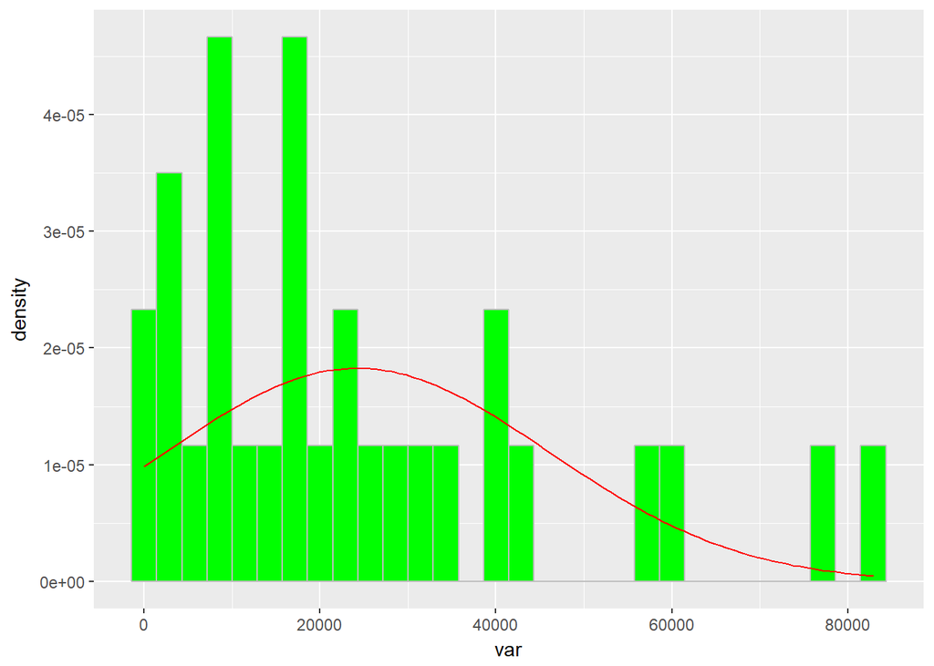

```r
library(ggplot2)
# keeping non missing:
data=projectData[is.finite(projectData$Value_of_Improvements),]
#
# selecting a var:
var=data$Value_of_Improvements
#
# saving mean and sd:
mnVar=mean(var,na.rm = T)
sdVar=sd(var,na.rm = T)
#
#plotting
base = ggplot(data, aes(x=var))
hist = base + geom_histogram(fill="green",
                             color='grey',
                          aes(y=..density..))
#
histAndNormal = hist + stat_function(fun=dnorm,
                                     color="red",
                                     args=list(mean=mnVar,sd=sdVar))
#
histAndNormal
```

Bivariate analysis: I will explore the relationship between the amount spent on improvements and secondary, numerical variables, by region.

```r
str(projectData)
```

```
## 'data.frame':    30 obs. of  10 variables:
##  $ Region_Code          : num  1 2 3 4 5 6 7 8 9 10 ...
##  $ Value_of_Repairs     : num  53194 3239 52391 17750 29268 ...
##  $ Value_of_Improvements: num  57007 17136 59211 17510 23536 ...
##  $ MPesa_Use            : num  1.72 1.56 1.45 1.77 1.64 ...
##  $ Ezy_Pesa_Use         : num  2 2 2 2 2 ...
##  $ Airtel_Use           : num  1.89 1.84 1.89 1.82 1.71 ...
##  $ Tigo_Pesa_Use        : num  1.9 1.93 1.77 1.66 1.58 ...
##  $ Wall_Material        : chr  "4" "2" "6" "2" ...
##  $ Roof_Material        : chr  "4" "4" "4" "4" ...
##  $ Floor_Material       : chr  "1" "1" "2" "1" ...
```

Compute the correlation between the value of improvments and other numerical variables:

```r
res <- cor(projectData[,c(2:7)],use='complete.obs')
round(res, 2)
```

```
##                       Value_of_Repairs Value_of_Improvements MPesa_Use
## Value_of_Repairs                  1.00                  0.02      0.15
## Value_of_Improvements             0.02                  1.00     -0.05
## MPesa_Use                         0.15                 -0.05      1.00
## Ezy_Pesa_Use                     -0.04                 -0.11     -0.64
## Airtel_Use                       -0.02                  0.11      0.07
## Tigo_Pesa_Use                    -0.42                 -0.16     -0.09
##                       Ezy_Pesa_Use Airtel_Use Tigo_Pesa_Use
## Value_of_Repairs             -0.04      -0.02         -0.42
## Value_of_Improvements        -0.11       0.11         -0.16
## MPesa_Use                    -0.64       0.07         -0.09
## Ezy_Pesa_Use                  1.00      -0.46         -0.04
## Airtel_Use                   -0.46       1.00          0.61
## Tigo_Pesa_Use                -0.04       0.61          1.00
```

Below is a visual representation of the correlation between value of improvments, value of repairs and use of one mobile money platform (MPesa):

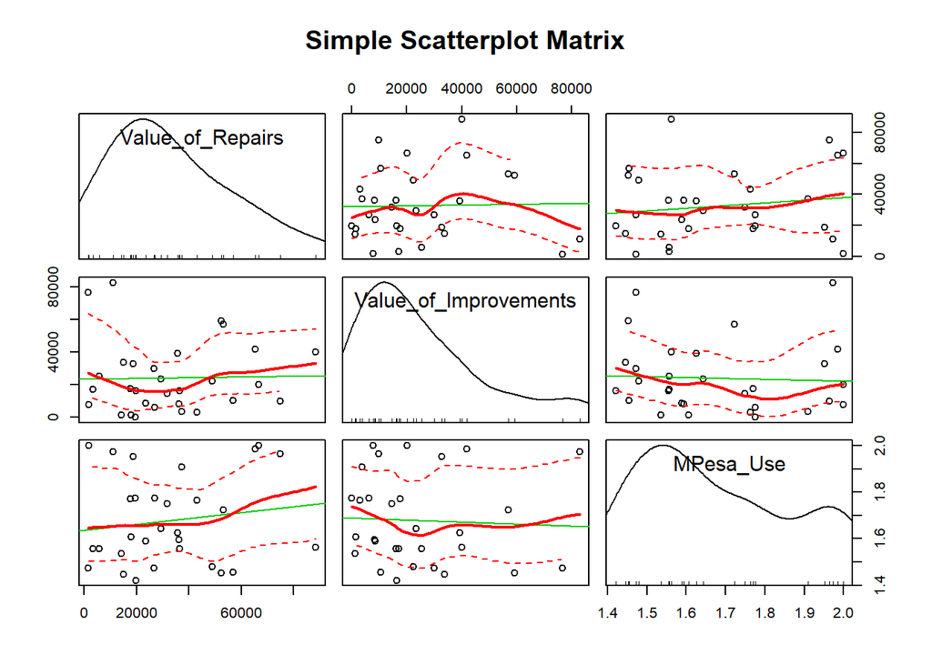

```r
library(car)
scatterplotMatrix(projectData[,c(2:4)],
   main="Simple Scatterplot Matrix")
```

Next we should explore the relationship between some of our categorical variables and our main numeric variable of interest, the value of improvments.

Let’s start by looking at at the relationship between the value of improvements and roof material. First, create a new variable which includes the names of the roofing material.

```r
projectData$Roof_Material_Name[projectData$Roof_Material==1] <- "Grass, Leaves, Bamboo"
projectData$Roof_Material_Name[projectData$Roof_Material==4] <- "Metal Sheets"
```

Next, create a box plot:

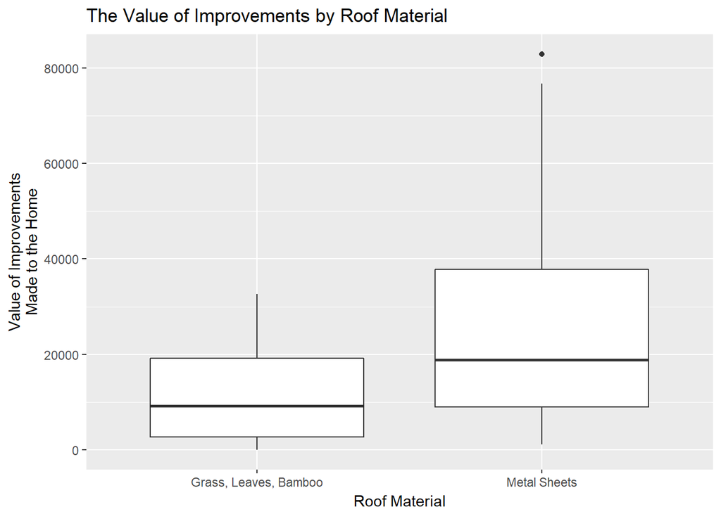

```r
projectData=projectData[complete.cases(projectData),]
p <- ggplot(projectData, aes(Roof_Material_Name,Value_of_Improvements))

p + geom_boxplot() + labs(title="The Value of Improvements by Roof Material") + scale_x_discrete(name = "Roof Material") +
        scale_y_continuous(name = "Value of Improvements\nMade to the Home")
```

Now create a new variable with the names of the wall material:

```r
projectData$Wall_Material_Name[projectData$Wall_Material==2] <- "Poles & Mud/Mud & Stones"
projectData$Wall_Material_Name[projectData$Wall_Material==4] <- "Mud Bricks"
projectData$Wall_Material_Name[projectData$Wall_Material==5] <- "Baked/Burnt Bricks"
projectData$Wall_Material_Name[projectData$Wall_Material==6] <- "Concrete, Cement, Stones"
```

And create a box plot:

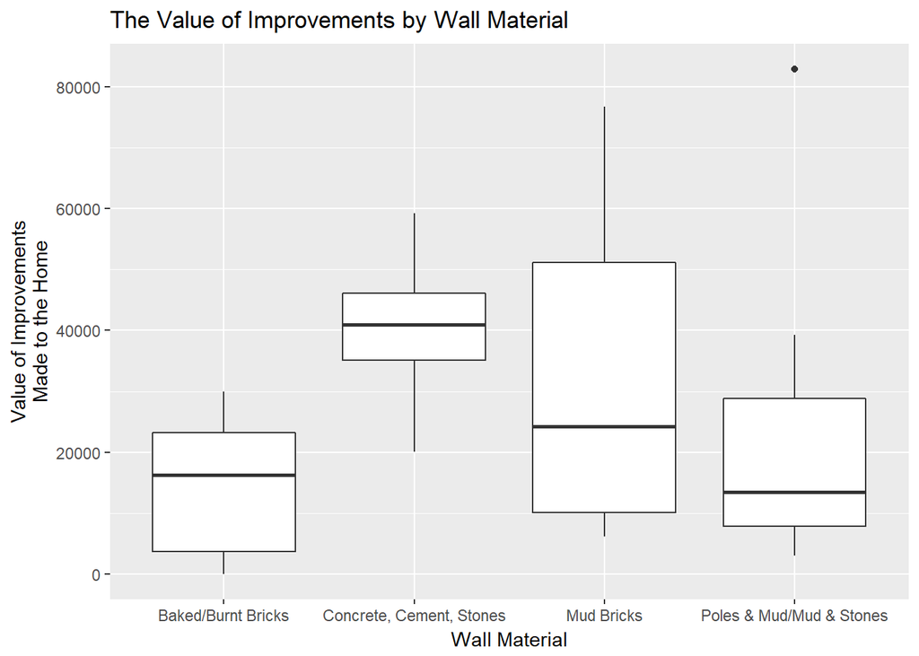

```r
projectData=projectData[complete.cases(projectData),]
p <- ggplot(projectData, aes(Wall_Material_Name,Value_of_Improvements))

p + geom_boxplot() + labs(title="The Value of Improvements by Wall Material")+scale_x_discrete(name = "Wall Material") +
        scale_y_continuous(name = "Value of Improvements\nMade to the Home")
```

Lastly, create a new variable with the names of the floor material:

```r
projectData$Floor_Material_Name[projectData$Floor_Material==1] <- "Earth"
projectData$Floor_Material_Name[projectData$Floor_Material==2] <- "Concrete, Cement, Tiles, Timber"
```

And create a box plot:

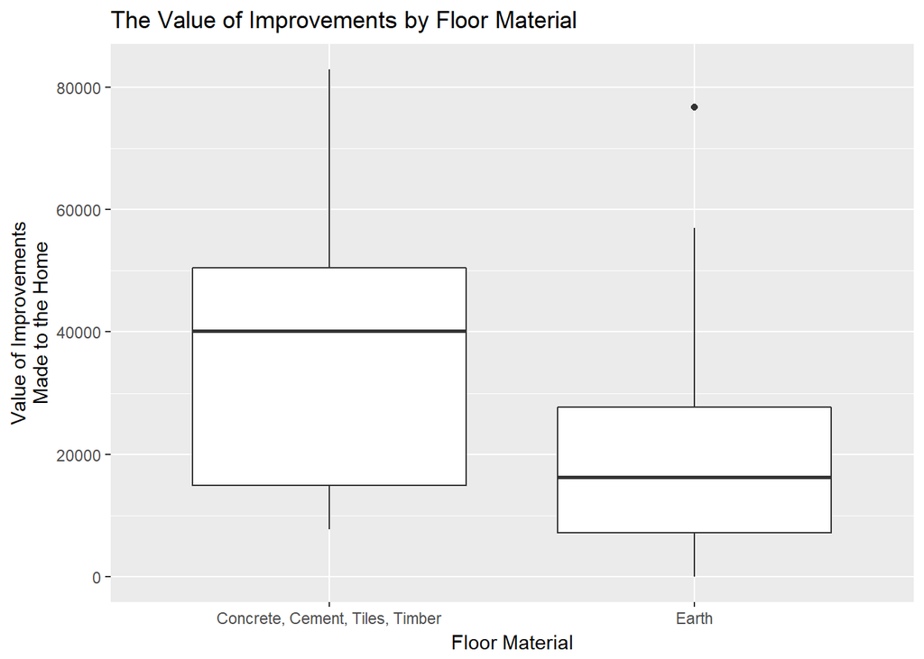

```r
projectData=projectData[complete.cases(projectData),]
p <- ggplot(projectData, aes(Floor_Material_Name,Value_of_Improvements))

p + geom_boxplot() + labs(title="The Value of Improvements by Floor Material")+scale_x_discrete(name = "Floor Material") +
        scale_y_continuous(name = "Value of Improvements\nMade to the Home")
```

Clustering: We will cluster variables by region and first need to confirm that every region only appears once.

```r
length(projectData$Region_Code)==length(unique(projectData$Region_Code))
```

```
## [1] TRUE
```

Now make the region the row name: Note for Emma: What happened to Region Name? Where did it get dropped? Where do I need to add it back?

```r
row.names(projectData)=projectData$Region_Code
```

Now double check the data of interest to make sure it is all the correct type:

```r
str(projectData[,c(1:7)])
```

```
## 'data.frame':    30 obs. of  7 variables:
##  $ Region_Code          : num  1 2 3 4 5 6 7 8 9 10 ...
##  $ Value_of_Repairs     : num  53194 3239 52391 17750 29268 ...
##  $ Value_of_Improvements: num  57007 17136 59211 17510 23536 ...
##  $ MPesa_Use            : num  1.72 1.56 1.45 1.77 1.64 ...
##  $ Ezy_Pesa_Use         : num  2 2 2 2 2 ...
##  $ Airtel_Use           : num  1.89 1.84 1.89 1.82 1.71 ...
##  $ Tigo_Pesa_Use        : num  1.9 1.93 1.77 1.66 1.58 ...
```

We may be concerned that use of different mobile money platforms are highly correlated, which would impact our clustering.

```r
res2 <- cor(projectData[,c(4:7)],use='complete.obs')
round(res2, 2)
```

```
##               MPesa_Use Ezy_Pesa_Use Airtel_Use Tigo_Pesa_Use
## MPesa_Use          1.00        -0.64       0.07         -0.09
## Ezy_Pesa_Use      -0.64         1.00      -0.46         -0.04
## Airtel_Use         0.07        -0.46       1.00          0.61
## Tigo_Pesa_Use     -0.09        -0.04       0.61          1.00
```

The above shows us that Airtel use and Tigo Pesa use are highly correlated, and that MPesa use and Ezy Pesa use are highly correlated. Because of this we will conduct clustering with only MPesa and Airtel use variables.

First we will produce a similarity matrix:

```r
library(cluster)

demoSimi=daisy(projectData[,c(1:4,6)],metric = "euclidean",
               stand=TRUE) # standardizing
```

apply the clustering technique:

```r
demoClus=hclust(demoSimi,method = 'average')
```

Now compare visually:

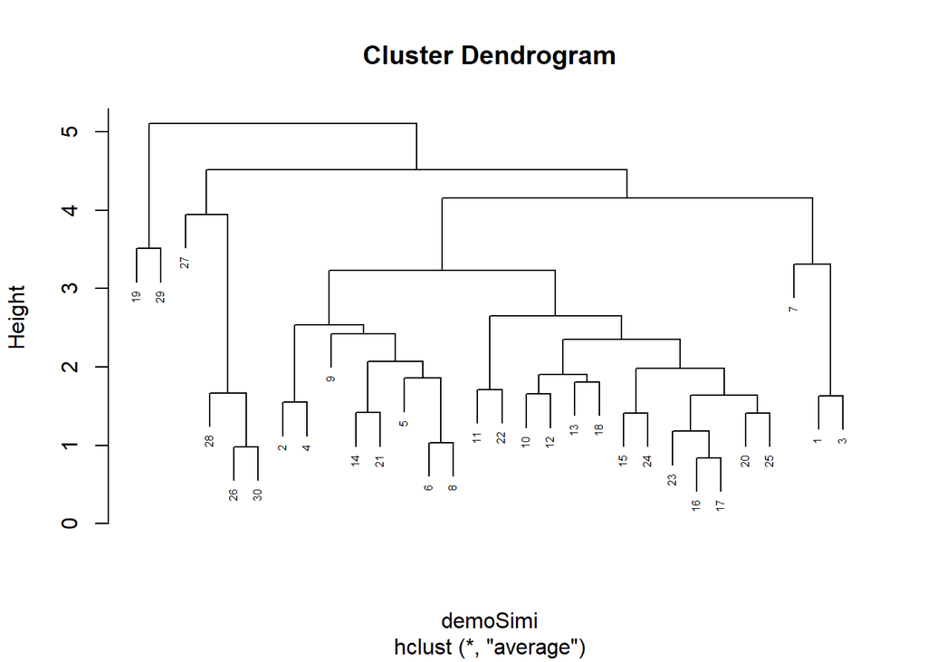

```r
plot(demoClus,cex=0.5)
```

Let’s try to cluster in 5 groups:

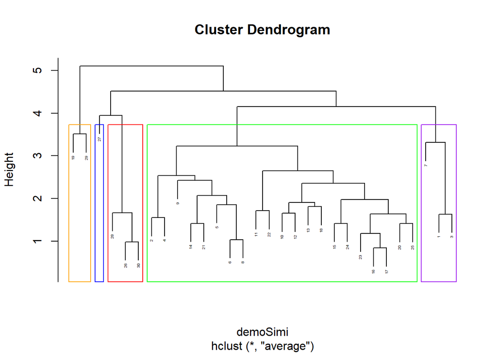

```r
plot(demoClus,cex=0.3)
rect.hclust(demoClus, k = 5,border = c('orange','blue','red','green','purple'))
```

Now let’s compare numerically:

```r
demsil5=silhouette(cutree(demoClus, k = 5), demoSimi)
clust5solution=data.frame(matrix(demsil5,ncol = 3,dimnames =dimnames(demsil5)))
row.names(clust5solution)=projectData$Region_Code
clust5solution
```

```
##    cluster neighbor   sil_width
## 1        1        2  0.36163899
## 2        2        1  0.32104667
## 3        1        2  0.37521384
## 4        2        1  0.32484732
## 5        2        1  0.15386191
## 6        2        1  0.21224304
## 7        1        2  0.28355016
## 8        2        1  0.27498747
## 9        2        1  0.17098806
## 10       2        1  0.33401043
## 11       2        1  0.14362184
## 12       2        1  0.24819146
## 13       2        1  0.28479506
## 14       2        1  0.39733235
```

[output cut: 16 more lines]

Let’s incorporate the cluster into our original data:

```r
# saving solution chosen
solution=clust5solution

# creating country column
solution$Region_Code=row.names(clust5solution)
row.names(solution)=NULL # resetting rownames

# merging
projectData=merge(projectData,solution)
```

Now let’s check the updated data frame:

```r
str(projectData)
```

```
## 'data.frame':    30 obs. of  16 variables:
##  $ Region_Code          : num  1 2 3 4 5 6 7 8 9 10 ...
##  $ Value_of_Repairs     : num  53194 3239 52391 17750 29268 ...
##  $ Value_of_Improvements: num  57007 17136 59211 17510 23536 ...
##  $ MPesa_Use            : num  1.72 1.56 1.45 1.77 1.64 ...
##  $ Ezy_Pesa_Use         : num  2 2 2 2 2 ...
##  $ Airtel_Use           : num  1.89 1.84 1.89 1.82 1.71 ...
##  $ Tigo_Pesa_Use        : num  1.9 1.93 1.77 1.66 1.58 ...
##  $ Wall_Material        : chr  "4" "2" "6" "2" ...
##  $ Roof_Material        : chr  "4" "4" "4" "4" ...
##  $ Floor_Material       : chr  "1" "1" "2" "1" ...
##  $ Roof_Material_Name   : chr  "Metal Sheets" "Metal Sheets" "Metal Sheets" "Metal Sheets" ...
##  $ Wall_Material_Name   : chr  "Mud Bricks" "Poles & Mud/Mud & Stones" "Concrete, Cement, Stones" "Poles & Mud/Mud & Stones" ...
##  $ Floor_Material_Name  : chr  "Earth" "Earth" "Concrete, Cement, Tiles, Timber" "Earth" ...
##  $ cluster              : num  1 2 1 2 2 2 1 2 2 2 ...
##  $ neighbor             : num  2 1 2 1 1 1 2 1 1 1 ...
##  $ sil_width            : num  0.362 0.321 0.375 0.325 0.154 ...
```

Let’s look at some of our variables of interest by cluster:

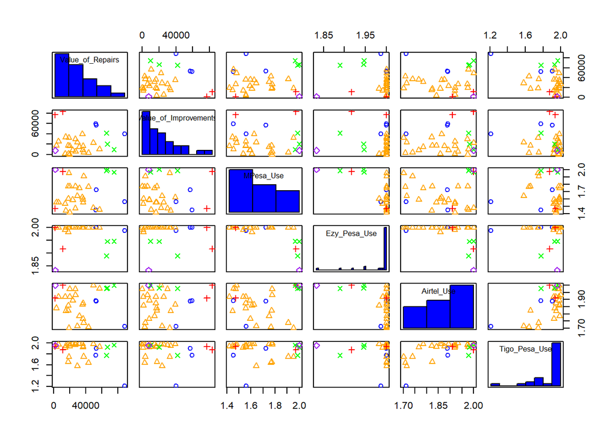

```r
palette=c('blue','orange','red','green','purple')
scatterplotMatrix(projectData[,c(2:7)], diagonal='histogram',reg.line=NULL , smoother=NULL,groups = projectData$cluster,col = palette,legend.plot=F)
```

Mapping Data: To map this data, we first need to bring in the shapefile for the regions:

```r
compressedMap= "https://github.com/efweavs1989/PUBPOL599B_Project/raw/master/TZA_adm_shp.zip"
```

```r
library(utils)
temp=tempfile()
download.file(compressedMap, temp)
unzip(temp)
```

Below we check which shapefiles are currently in our directories:

```r
(maps=list.files(pattern = 'shp'))
```

```
## [1] "TZA_adm_shp.zip" "TZA_adm0.shp"    "TZA_adm1.shp"    "TZA_adm2.shp"
## [5] "TZA_adm3.shp"
```

We are interested in “TZA_adm1” because this is for the country and region level only.

Now we select that map:

```r
library(rgdal)
TZMap <- rgdal::readOGR("TZA_adm1.shp",stringsAsFactors=F) # use name
names(TZMap)
```

```
##  [1] "ID_0"      "ISO"       "NAME_0"    "ID_1"      "NAME_1"
##  [6] "HASC_1"    "CCN_1"     "CCA_1"     "TYPE_1"    "ENGTYPE_1"
## [11] "NL_NAME_1" "VARNAME_1"
```

Just keep the region code data:

```r
TZMap=TZMap[,c('ID_1')]
```

Let’s check the data type of the column which includes the region code:

```r
str(TZMap$ID_1)
```

```
##  chr [1:30] "1" "2" "3" "4" "5" "6" "7" "8" "9" "10" "11" "12" "13" ...
```

This is an integer in our other data, so let’s convert this to an integer:

```r
TZMap$ID_1=as.numeric(TZMap$ID_1)
```

```r
str(TZMap$ID_1)
```

```
##  num [1:30] 1 2 3 4 5 6 7 8 9 10 ...
```

Now let’s merge:

```r
contribTZmap=merge(TZMap,projectData, by.x='ID_1', by.y='Region_Code',all.x=F)
```

Install the packages required for managing color and divisions when plotting:

```r
library(RColorBrewer)
library(classInt)
```

First, let’s plot the clusters created previously:

```r
varToPLot=projectData$cluster
```

Get colors and intervals

```r
numberOfClasses = 5
colorForScale='YlGnBu'
colors = brewer.pal(numberOfClasses, colorForScale)
intervals <- classIntervals(varToPLot, numberOfClasses,
                            style = "quantile",
                            dataPrecision=2)
colorPallette <- findColours(intervals, colors)
```

Plot:

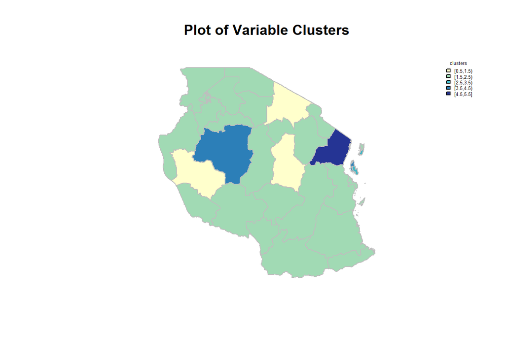

```r
legendText="clusters"
shrinkLegend=0.4
title="Plot of Variable Clusters"

plot(contribTZmap,col='purple',main=title)
plot(contribTZmap, col = colorPallette,border='grey',add=T)

legend('topright', legend = names(attr(colorPallette, "table")),
       fill = attr(colorPallette, "palette"), cex = shrinkLegend,
       bty = "n",
       title=legendText)
```

Now plot the value of improvements:

```r
varToPLot=projectData$Value_of_Improvements
```

Get colors and intervals

```r
numberOfClasses = 5
colorForScale='YlGnBu'
colors = brewer.pal(numberOfClasses, colorForScale)
intervals <- classIntervals(varToPLot, numberOfClasses,
                            style = "quantile",
                            dataPrecision=2)
colorPallette <- findColours(intervals, colors)
```

Plot:

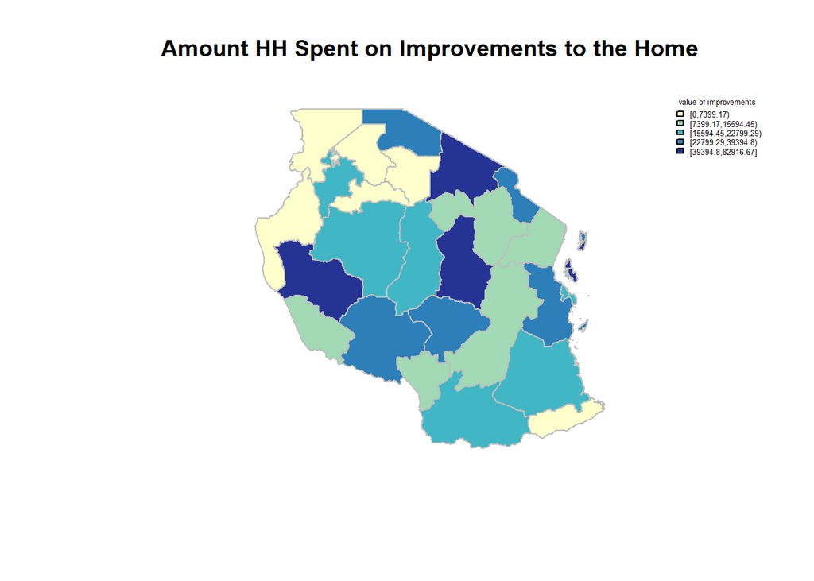

```r
legendText="value of improvements"
shrinkLegend=0.4
title="Amount HH Spent on Improvements to the Home"

plot(contribTZmap,col='purple',main=title)
plot(contribTZmap, col = colorPallette,border='grey',add=T)

legend('topright', legend = names(attr(colorPallette, "table")),
       fill = attr(colorPallette, "palette"), cex = shrinkLegend,
       bty = "n",
       title=legendText)
```

Now plot the value of repairs:

```r
varToPLot=projectData$Value_of_Repairs
```

Get colors and intervals

```r
numberOfClasses = 5
colorForScale='YlGnBu'
colors = brewer.pal(numberOfClasses, colorForScale)
intervals <- classIntervals(varToPLot, numberOfClasses,
                            style = "quantile",
                            dataPrecision=2)
colorPallette <- findColours(intervals, colors)
```

Plot:

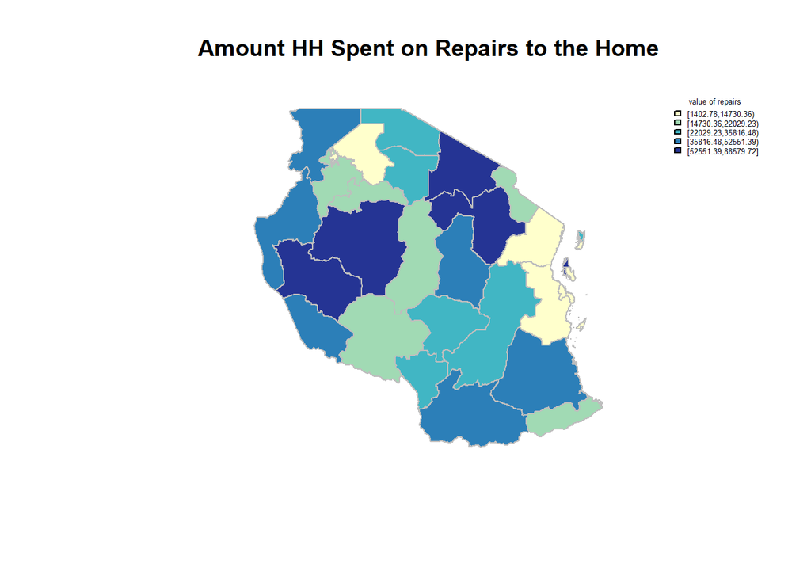

```r
legendText="value of repairs"
shrinkLegend=0.4
title="Amount HH Spent on Repairs to the Home"

plot(contribTZmap,col='purple',main=title)
plot(contribTZmap, col = colorPallette,border='grey',add=T)

legend('topright', legend = names(attr(colorPallette, "table")),
       fill = attr(colorPallette, "palette"), cex = shrinkLegend,
       bty = "n",
       title=legendText)
```

Plot the use of MPesa, one of the mobile money platforms used in the survey:

```r
varToPLot=projectData$MPesa_Use
```

Get colors and intervals

```r
numberOfClasses = 5
colorForScale='YlGnBu'
colors = brewer.pal(numberOfClasses, colorForScale)
intervals <- classIntervals(varToPLot, numberOfClasses,
                            style = "quantile",
                            dataPrecision=2)
colorPallette <- findColours(intervals, colors)
```

Plot:

[figure not shown]

```r
legendText="MPesa Use"
shrinkLegend=0.4
title="Does the HH Use Mobile Money (MPesa)"

plot(contribTZmap,col='purple',main=title)
plot(contribTZmap, col = colorPallette,border='grey',add=T)

legend('topright', legend = names(attr(colorPallette, "table")),
       fill = attr(colorPallette, "palette"), cex = shrinkLegend,
       bty = "n",
       title=legendText)
```